# Iron Repletion in HFpEF

- Show All Code
- Hide All Code
- View Source

Credit for the analysis, caution for the interpretation — beware of the winner’s curse

A critical look at the IRONMET-HFpEF trial: ANCOVA, Bayesian re-analysis and the winner’s curse

Bayesian inference

RCTs

winner's curse

heart failure

Author

Affiliation

[Jay Brophy](https://brophyj.github.io/)

[McGill University Dept Medicine, Epidemiology & Biostatistics](https://mcgill.ca)

Published

Monday, the 16th of November, 2026

Lewis and colleagues recently published the IRONMET-HFpEF (Impact of Intravenous Iron Repletion on Mechanisms of Exercise Intolerance in HFpEF) trial (1) seeking to determine whether ferric derisomaltose (FDI) compared with placebo improves exercise capacity as objectively measured by peak oxygen uptake (Vo2) at 12 weeks in heart failure with preserved ejection fraction and iron deficiency. The authors deserve credit for prespecifying covariance (ANCOVA) as their primary analytic method since baseline and 12-week peak V̇O₂ are highly correlated (r ≈ 0.94, derivable from their Table 2), so ANCOVA is about three times more precise than simply comparing week-12 values (1.2 mL·kg⁻¹·min⁻¹, 95% CI −1.3 to 3.7).

```r
# Inputs: Lewis et al., Circulation 2026, Table 2 (peak VO2, mL/kg/min)
n_f <- 43; n_p <- 21; k <- sqrt(1 / n_f + 1 / n_p); df <- n_f + n_p - 3
anc   <- c(est = 1.1, lo = 0.2, hi = 1.9)                     # published ANCOVA difference
se_an <- unname((anc["hi"] - anc["lo"]) / (2 * qt(0.975, df)))
s_e   <- se_an / k                                            # residual SD (about 1.6)
s_b   <- sqrt((43 * 4.2^2 + 20 * 4.1^2) / 63)                 # pooled SD, baseline
s_f   <- sqrt((42 * 5.0^2 + 20 * 3.7^2) / 62)                 # pooled SD, week 12
r_hat <- sqrt(1 - s_e^2 / s_f^2)                              # implied correlation (about 0.94)
# week-12 values only: difference and 95% CI
fu <- 14.9 - 13.7; se_fu <- s_f * k
round(c(r = r_hat, fu = fu, lo = fu - qt(0.975, df) * se_fu, hi = fu + qt(0.975, df) * se_fu,
        precision_ratio = se_fu / se_an), 2)
```

```
              r              fu              lo              hi precision_ratio
           0.94            1.20           -1.26            3.66            2.89
```

However I am less persuaded by their interpretation.

First, the Abstract leads with within-group changes: peak V̇O₂ “improved” with ferric derisomaltose (FDI) and was “unchanged” with placebo. Such comparisons against baseline are not randomized and can be highly misleading (2); only the between-group difference tests the treatment.

Second, the difference of 1.1 mL·kg⁻¹·min⁻¹ (0.2 to 1.9) is said to “exceed” the minimal clinically important difference (MCID) of 1.0. In a Bayesian re-analysis with a vague prior, so that the data dominate the posterior distribution, the probability that the true effect exceeds the MCID is 59%. With an empirical Bayes prior based on 23,551 Cochrane trials (3), the estimate shrinks to 0.76 mL·kg⁻¹·min⁻¹ and the probability of exceeding the MCID to 29%.

```r
y <- 1.1; s <- se_an; z_obs <- y / s; N <- 2e5; mcid <- 1
# vague prior N(0, 10^2): conjugate normal update
w0 <- 1 / 10^2; w <- 1 / s^2
m1 <- (w * y) / (w0 + w); s1 <- sqrt(1 / (w0 + w))
p_vague <- 1 - pnorm(mcid, m1, s1)                           # about 0.59
# empirical Bayes: van Zwet et al. (NEJM Evid 2024) mixture for Cochrane trials
sd_z <- c(1.17, 1.74, 2.38, 5.73); p_mix <- c(0.32, 0.31, 0.30, 0.07)
sd_snr <- sqrt(sd_z^2 - 1); Bk <- sd_snr^2 / (sd_snr^2 + 1)
wp <- p_mix * dnorm(z_obs, 0, sd_z); wp <- wp / sum(wp)
set.seed(2026)
cc <- sample.int(4, N, TRUE, wp)
eb <- rnorm(N, Bk[cc] * z_obs, sqrt(Bk[cc])) * s             # back to mL/kg/min
round(c(p_vague = p_vague, eb_median = median(eb), p_eb = mean(eb > mcid)), 2)
```

```
  p_vague eb_median      p_eb
     0.59      0.76      0.29
```

Third, the trial had less power than planned: the residual SD (≈1.6) exceeded the 1.25 assumed, giving about 64% power for the MCID. When power is modest, the trials that reach statistical significance are disproportionately those in which chance inflated the effect, the “winner’s curse” (4). Estimating the effect from a likelihood that accounts for this selection (5) gives 0.58 mL·kg⁻¹·min⁻¹ (95% CI −0.15 to 1.80); with a vague prior, the probability that this effect exceeds the MCID is 31%.

```r
power_mcid <- 1 - pt(qt(0.975, df) - 1 / se_an, df) + pt(-qt(0.975, df) - 1 / se_an, df)  # about 0.64
# likelihood conditional on statistical significance (Zhong & Prentice 2008)
z_crit <- qt(0.975, df)
cond_ll <- function(th) dt((y - th) / se_an, df, log = TRUE) -
  log(1 - pt(z_crit - th / se_an, df) + pt(-z_crit - th / se_an, df))
th <- seq(-2, 3, by = 0.001); ll <- sapply(th, cond_ll)
mle <- th[which.max(ll)]                                     # about 0.58
ci  <- range(th[ll > max(ll) - qchisq(0.95, 1) / 2])         # about -0.15 to 1.80
pc  <- exp(ll - max(ll)); pc <- pc / sum(pc)                 # vague (flat) prior posterior
round(c(power = power_mcid, mle = mle, lo = ci[1], hi = ci[2], p_mcid = sum(pc[th > mcid])), 2)
```

```
 power    mle     lo     hi p_mcid
  0.64   0.58  -0.15   1.80   0.31
```

```r
# Winner's curse: 10,000 trials like IRONMET-HFpEF (43 FDI, 21 placebo,
# residual SD as observed) with a true difference of 0.5 mL/kg/min (half the MCID)
library(tidyverse)
clr_post <- "#31a354"; clr_lik <- "#e6550d"; clr_sig <- "#756bb1"
set.seed(629)
true_d <- 0.5
sims <- tibble(m1 = rnorm(1e4, true_d, s_e / sqrt(n_f)),          # mean change, FDI
               m0 = rnorm(1e4, 0,      s_e / sqrt(n_p)),          # mean change, placebo
               sp = s_e * sqrt(rchisq(1e4, df) / df)) |>          # estimated residual SD
  mutate(d   = m1 - m0,
         se  = sp * k,
         sig = abs(d / se) > qt(0.975, df))
round(c(power = mean(sims$sig), mean_sig = mean(abs(sims$d[sims$sig])),
        type_m = mean(abs(sims$d[sims$sig])) / true_d), 2)
```

```
   power mean_sig   type_m
    0.21     1.07     2.14
```

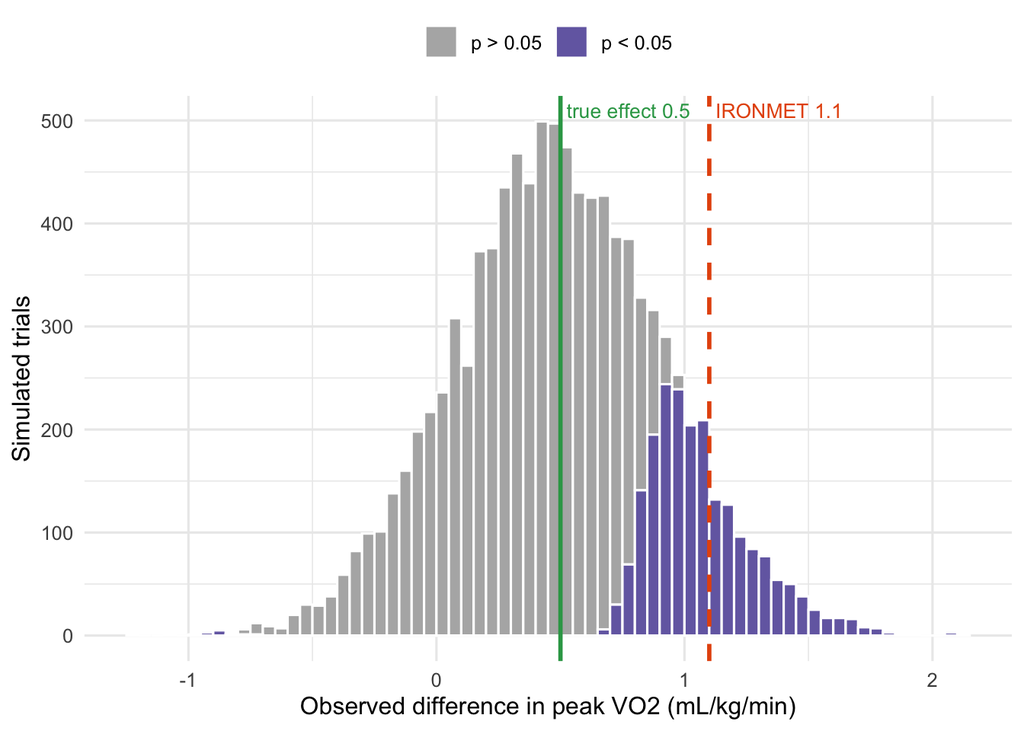

```r
ggplot(sims, aes(d, fill = sig)) +
  geom_histogram(binwidth = 0.05, colour = "white", boundary = 0) +
  geom_vline(xintercept = true_d, linewidth = 1, colour = clr_post) +
  geom_vline(xintercept = 1.1, linetype = 2, colour = clr_lik, linewidth = 1) +
  annotate("text", x = c(true_d, 1.1), y = Inf, vjust = 1.5, hjust = -0.05, size = 3.5,
           label = c("true effect 0.5", "IRONMET 1.1"), colour = c(clr_post, clr_lik)) +
  scale_fill_manual(values = c(`FALSE` = "grey70", `TRUE` = clr_sig),
                    labels = c("p > 0.05", "p < 0.05"), name = NULL) +
  labs(x = "Observed difference in peak VO2 (mL/kg/min)", y = "Simulated trials") +
  theme_minimal(base_size = 12) + theme(legend.position = "top")
```

Fourth, the secondary outcomes that “also improved” are correlated measures of one construct, without multiplicity control, while the only patient-reported outcome, the KCCQ, did not differ (4.4, −2.4 to 11.2). With 21 controls, randomization ensures exchangeability only on average; the placebo group was older and had more diabetes. Randomizing 65 of 89 assessed patients over 52 months suggests a highly selected population, and generalizing these results to an unselected population may be problematic.

Given that these data are consistent with a modest increase in peak V̇O₂ of uncertain clinical importance, a more cautious conclusion than “FDI improved multiple measures of exercise capacity” would better reflect the evidence and better inform readers.

**Disclosures:** None.

## References

1.

Lewis GD, Horick NK, Moreno F, et al. [Iron repletion in heart failure with preserved ejection fraction: The IRONMET-HFpEF randomized trial](https://doi.org/10.1161/CIRCULATIONAHA.126.084009). Circulation. 2026;154.

2.

Bland JM, Altman DG. [Comparisons against baseline within randomised groups are often used and can be highly misleading](https://doi.org/10.1186/1745-6215-12-264). Trials. 2011;12:264.

3.

van Zwet E, Gelman A, Greenland S, Imbens G, Schwab S, Goodman SN. [A new look at P values for randomized clinical trials](https://doi.org/10.1056/EVIDoa2300003). NEJM Evidence. 2024;3(1):EVIDoa2300003.

4.

Gelman A, Carlin J. [Beyond power calculations: Assessing Type S (sign) and Type M (magnitude) errors](https://doi.org/10.1177/1745691614551642). Perspectives on Psychological Science. 2014;9(6):641–51.

5.

Zhong H, Prentice RL. [Bias-reduced estimators and confidence intervals for odds ratios in genome-wide association studies](https://doi.org/10.1093/biostatistics/kxn001). Biostatistics. 2008;9(4):621–34.